# Business Problem Statement:

TikTok's eCommerce team is striving to optimize the marketing campaigns for various products within the TikTok platform. The primary objectives include identifying the ideal target audience, optimizing spending on marketing, predicting the users' behaviors, and evaluating the efficiency of different advertising channels. We aim to analyze the historical data to uncover insights that could drive higher engagement, increase daily active users (DAU), and generate more revenue through product sales. Specifically, the challenge is to understand how users interact with ads, identify any unusual behavior, and formulate strategies to boost eCommerce activities within the app.

## Data Tables:

#### Table 1: `user_activity`

| Column Name | Description | Feature Type |
| --- | --- | --- |
| user_id | Unique identifier for users | Categorical |
| campaign_id | Unique identifier for marketing campaigns | Categorical |
| timestamp | Timestamp of the activity | Datetime |
| product_id | Unique identifier for products | Categorical |
| action_type | Action type (e.g., click, view, purchase) | Categorical |
| platform | Platform where the activity occurred (e.g., iOS, Android) | Categorical |

#### Table 2: `marketing_campaigns`

| Column Name | Description | Feature Type |
| --- | --- | --- |
| campaign_id | Unique identifier for marketing campaigns | Categorical |
| start_date | Start date of the campaign | Datetime |
| end_date | End date of the campaign | Datetime |
| budget | Budget allocated for the campaign | Numeric |
| channel | Marketing channel (e.g., social media, email) | Categorical |

## Questions:

1. **SQL and Analytics**: Identify the top 3 products that have the most interactions from 2022-01-01 to 2022-12-31, and evaluate how different marketing channels have influenced these interactions. Then, propose a strategy to optimize marketing spend based on this analysis.
2. **Progressive Machine Learning & Modeling**:
   - a. Utilizing the `user_activity` and `marketing_campaigns` tables, develop a predictive model that could detect any unusual (or wired) behavior in users' interactions with products.
   - b. Analyze the importance of features within your model and identify the trade-offs between different hyperparameters such as learning rate. Explain your choice of algorithm (e.g., Random Forest, XGBoost).
   - c. Use the insights from the model to propose how we can improve the performance of the eCommerce activities within the TikTok platform.
3. **Product Design & Analytics**: Analyze the patterns of user behavior across different platforms (e.g., iOS, Android) and for different actions (e.g., click, view, purchase). Then, design a case study to test a new marketing strategy that could potentially increase DAU.
   - a. Outline the process of AB testing you would follow to validate this strategy.
   - b. Explain how you would measure success and the key metrics involved.
4. **Probability and Statistics Question**: Given a product and its marketing campaigns, estimate the probability of a user purchasing the product after viewing an ad. Use causal knowledge to explain how different factors might affect this probability.

## Load data

```python
# Load the dataframes from csv files
import pandas as pd

user_activity = pd.read_csv("https://storage.googleapis.com/datalynn-datasets/interview-challenge/technology/Tiktok_eCommerce/user_activity.csv")
marketing_campaigns = pd.read_csv("https://storage.googleapis.com/datalynn-datasets/interview-challenge/technology/Tiktok_eCommerce/marketing_campaigns.csv")
```

## Q1

**Original Question**:

Identify the top 3 products that have the most interactions from 2022-01-01 to 2022-12-31, and evaluate how different marketing channels have influenced these interactions. Then, propose a strategy to optimize marketing spend based on this analysis.

### Solution

The solution to this problem can be broken down into three major parts:

1. **Identify the top 3 products that have the most interactions within a given time frame.**
2. **Evaluate how different marketing channels have influenced these interactions.**
3. **Propose a strategy to optimize marketing spend based on this analysis.**

#### SQL Solution:

```python
import sqlite3
import pandas as pd

# Create an in-memory SQLite database
conn = sqlite3.connect(':memory:')

# Convert dataframes into SQLite tables
user_activity.to_sql('user_activity', conn, if_exists='replace', index=False)
marketing_campaigns.to_sql('marketing_campaigns', conn, if_exists='replace', index=False)

# Part 1: Top 3 products with most interactions
top_products_query = """
WITH TopProducts AS (
    SELECT product_id,
           COUNT(*) as interactions
    FROM user_activity
    WHERE timestamp BETWEEN '2022-01-01' AND '2022-12-31'
    GROUP BY product_id
    ORDER BY interactions DESC
    LIMIT 3
)
SELECT * FROM TopProducts;
"""

top_products_df = pd.read_sql_query(top_products_query, conn)

# Part 2: Evaluate marketing channels for the top 3 products
evaluate_channels_query = """
WITH TopProducts AS (
    SELECT product_id,
           COUNT(*) as interactions
    FROM user_activity
    WHERE timestamp BETWEEN '2022-01-01' AND '2022-12-31'
    GROUP BY product_id
    ORDER BY interactions DESC
    LIMIT 3
)
SELECT mc.channel,
       tp.product_id,
       COUNT(ua.action_type) as interactions
FROM TopProducts tp
JOIN user_activity ua ON tp.product_id = ua.product_id
JOIN marketing_campaigns mc ON ua.timestamp BETWEEN mc.start_date AND mc.end_date
WHERE ua.timestamp BETWEEN '2022-01-01' AND '2022-12-31'
GROUP BY mc.channel, tp.product_id;
"""

evaluate_channels_df = pd.read_sql_query(evaluate_channels_query, conn)

# Now you can close the connection
conn.close()

# You can print the resulting dataframes or process them further
print(top_products_df)
print(evaluate_channels_df)
```

```
   product_id  interactions
0          87            87
1          15            86
2          88            82
         channel  product_id  interactions
0             TV          15            57
1             TV          87            39
2             TV          88            35
3          email          15            19
4          email          87            12
5          email          88            24
6     influencer          15            18
7     influencer          87            24
8     influencer          88             6
9         search          15            54
10        search          87            31
11        search          88            43
12  social media          15            76
13  social media          87            70
14  social media          88            93
```

#### Python Pandas Solution:

```
product_id     15   87   88
channel
TV            5.0  1.0  5.0
email         0.0  1.0  0.0
influencer    0.0  5.0  1.0
search        3.0  1.0  2.0
social media  0.0  4.0  2.0
```

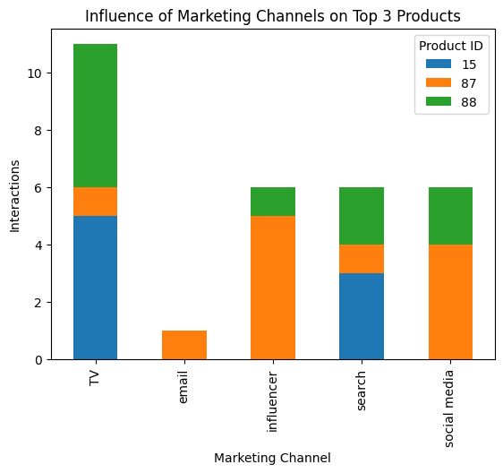

```
        channel  interactions
0            TV            11
1         email             1
2    influencer             6
3        search             6
4  social media             6
```

```python
import pandas as pd
import matplotlib.pyplot as plt

# Define the start and end dates
start_date = '2022-01-01'
end_date = '2022-12-31'

# Part 1: Identify the top 3 products within the given time frame
top_products = user_activity[
    (user_activity['timestamp'] >= start_date) & (user_activity['timestamp'] <= end_date)
].groupby('product_id').size().reset_index(name='interactions').nlargest(3, 'interactions')

# Part 2: Evaluate marketing channels for the top 3 products
# First, filter the user_activity data to only include the top 3 products
top_products_activity = user_activity[user_activity['product_id'].isin(top_products['product_id'])]

# Filter the marketing campaigns within the given time frame
filtered_campaigns = marketing_campaigns[
    (marketing_campaigns['start_date'] >= start_date) & (marketing_campaigns['end_date'] <= end_date)
]

# Join the filtered user activity with the filtered marketing campaigns
merged_data = pd.merge(
    top_products_activity,
    filtered_campaigns,
    left_on='timestamp',
    right_on='start_date',
    how='inner'
)

# Group by marketing channel and product ID to get the interactions count
channel_influence = merged_data.groupby(['channel', 'product_id']).size().reset_index(name='interactions')

# Pivot the data to get a better visualization of how channels influence different products
pivot_channel_influence = channel_influence.pivot(index='channel', columns='product_id', values='interactions').fillna(0)

# Print the result
print(pivot_channel_influence)

# Plotting the result for better visualization
pivot_channel_influence.plot(kind='bar', stacked=True)
plt.title('Influence of Marketing Channels on Top 3 Products')
plt.xlabel('Marketing Channel')
plt.ylabel('Interactions')
plt.legend(title='Product ID')
plt.show()

# Additional validation, such as summarizing the total interactions per channel
channel_summary = channel_influence.groupby('channel')['interactions'].sum().reset_index()
print(channel_summary)
```

## Q2

**Original Question**:

**Progressive Machine Learning & Modeling**:

- a. Utilizing the `user_activity` and `marketing_campaigns` tables, develop a predictive model that could detect any unusual (or wired) behavior in users' interactions with products.
- b. Analyze the importance of features within your model and identify the trade-offs between different hyperparameters such as learning rate. Explain your choice of algorithm (e.g., Random Forest, XGBoost).
- c. Use the insights from the model to propose how we can improve the performance of the eCommerce activities within the TikTok platform.

### Solution

#### Problem Solving Ideas and Tips:

Detecting unusual or anomalous behavior in user interactions is a significant task for identifying fraudulent or atypical actions. This can be done using various machine learning techniques, and since it is an anomaly detection task, methods like Isolation Forest, One-Class SVM, and clustering algorithms can be used.

The unusual behavior could include sudden spikes in clicks or purchases, interactions with products at odd hours, etc. We can create features like average time spent on products, number of clicks, number of purchases, etc., to train our model.

The following solution outlines the steps to create a predictive model to detect unusual behavior.

#### Solution:

```python
import pandas as pd
from sklearn.ensemble import IsolationForest
from sklearn.model_selection import train_test_split
from sklearn.preprocessing import LabelEncoder
from sklearn.metrics import classification_report
import warnings
warnings.filterwarnings('ignore')

# Joining the tables on relevant keys (if required)
# Here we'll only consider the user_activity table as we are focusing on user interactions

# Feature Engineering
# Convert the 'timestamp' column to a datetime type
user_activity['timestamp'] = pd.to_datetime(user_activity['timestamp'])

# Convert timestamp to day of the day
user_activity['day_of_week'] = user_activity['timestamp'].dt.dayofweek

# Label encode categorical features
label_encoders = {}
for column in ['product_id', 'action_type', 'platform']:
    le = LabelEncoder()
    user_activity[column] = le.fit_transform(user_activity[column])
    label_encoders[column] = le

# Define target variable for unusual behavior (e.g., you can set 1 for known unusual behavior for training, else 0)
# Here, we assume that it's an unsupervised problem, so we don't have labels for unusual behavior

# Select features for the model
features = [ 'product_id', 'action_type', 'platform', 'day_of_week']
X = user_activity[features]

# Splitting the data
X_train, X_test = train_test_split(X, test_size=0.2, random_state=42)

# Building the Isolation Forest Model
model = IsolationForest(contamination=0.01)  # contamination parameter can be tuned
model.fit(X_train)

# Predicting anomalies
predictions = model.predict(X_test)

# Converting the prediction to a binary outcome (1 for unusual, 0 for normal)
predictions[predictions == 1] = 0
predictions[predictions == -1] = 1
```

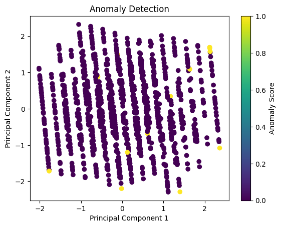

```python
from sklearn.preprocessing import StandardScaler
from sklearn.decomposition import PCA
import matplotlib.pyplot as plt

# Standardize the features
scaler = StandardScaler()
X_test_standardized = scaler.fit_transform(X_test)

# Apply PCA to the standardized features
pca = PCA(n_components=2)
X_test_transformed = pca.fit_transform(X_test_standardized)

# Plotting the results
plt.scatter(X_test_transformed[:, 0], X_test_transformed[:, 1], c=predictions, cmap='viridis')
plt.title("Anomaly Detection")
plt.xlabel("Principal Component 1")
plt.ylabel("Principal Component 2")
plt.colorbar(label="Anomaly Score")
plt.show()
```

### Solution

#### Feature Importance Analysis:

Analyzing feature importance helps in understanding which features contribute the most to the model's decision-making process. This understanding can help in model interpretability and in selecting or engineering more useful features.

In the case of the Isolation Forest algorithm, feature importance is not directly available as it is for some other tree-based models like Random Forest. However, we can use techniques like permutation importance to estimate the importance of different features.

#### Choice of Algorithm (Isolation Forest):

Isolation Forest is particularly useful for anomaly detection. It's designed to isolate anomalies instead of constructing a profile of normal instances.

1. **Efficiency**: Unlike traditional methods, Isolation Forest does not calculate distances, densities, or nearest neighbors, making it highly efficient.
2. **Unsupervised Learning**: It can work in an unsupervised setting where we don't have labels for the anomalies.
3. **Works with High Dimensions**: It can handle high-dimensional data well.

#### Hyperparameter Trade-offs:

1. **`n_estimators`**: The number of trees in the forest.
   - **Trade-off**: Increasing the number of trees improves accuracy but slows down computation.
   - **Typical values**: 100 - 300
2. **`max_samples`**: The number of samples to be drawn to train each base estimator.
   - **Trade-off**: A larger `max_samples` might increase accuracy but also increase computation time.
   - **Typical values**: 'auto', 256, etc.
3. **`contamination`**: Proportion of outliers in the data set.
   - **Trade-off**: Setting this too high might result in too many false positives, while setting it too low might miss actual anomalies.
   - **Typical values**: 0.01 - 0.05
4. **Learning Rate**: Isolation Forest doesn't have a learning rate parameter since it's not an iterative algorithm like Gradient Boosting or Neural Networks.

#### Conclusion:

The choice of Isolation Forest is motivated by its efficiency and suitability for unsupervised anomaly detection. By considering the trade-offs of hyperparameters, you can tune the model for the specific requirements of accuracy, computational efficiency, and alignment with the underlying data distribution. By analyzing feature importance, you can gain insights into what factors are driving the model's decisions, which can inform further feature engineering or model refinement.

### Solution

#### Insights from the Anomaly Detection Model:

By analyzing the unusual user behaviors detected by the model, we can draw several insights that might be instrumental in improving the eCommerce activities within the TikTok platform.

1. **Time Patterns**: The day of the week may reveal patterns where certain products are more frequently interacted with on specific days. This can guide promotional efforts.
2. **Platform Differences**: Differences in user behavior across platforms (iOS vs. Android) might indicate areas for UX improvements or tailored marketing strategies.
3. **Action-Type Analysis**: Analyzing the frequency and patterns of clicks, views, and purchases can provide insights into user preferences and behavior.
4. **Identifying Fraudulent Behavior**: If any fraudulent or bot-like behavior is detected (e.g., a large number of clicks but no purchases), measures can be implemented to prevent such activities, ensuring genuine user engagement.

#### Strategies to Improve eCommerce Activities:

1. **Personalized Marketing**: Based on user behavior and interactions with products, develop personalized recommendations and advertisements. For example, promoting products that have a higher click-through rate on specific days.
2. **Optimize User Experience (UX)**: If anomalies are detected in how users interact with the platform on different devices, this can be an opportunity to optimize the app's user experience to make navigation and purchasing more intuitive.
3. **Dynamic Pricing**: If unusual behavior is detected around certain products or during specific days, dynamic pricing strategies can be implemented to boost sales.
4. **Enhance Fraud Detection**: Implementing real-time anomaly detection can reduce fraudulent activities and ensure that marketing and sales efforts are targeting genuine users.
5. **Channel Optimization**: Utilize the insights to focus on the most effective channels (e.g., iOS or Android users) for different product categories.
6. **Collaboration with Marketing Campaigns**: By aligning the insights with ongoing or future marketing campaigns, marketing strategies can be optimized to target users more effectively.
7. **Seasonality and Trend Analysis**: Understanding trends and seasonal patterns in user behavior can allow for targeted marketing during peak interest times.

#### Conclusion:

The insights derived from the anomaly detection model provide a comprehensive view of how users interact with the platform. By understanding these patterns, TikTok's eCommerce team can make data-driven decisions that align with user behavior. This might include personalized marketing, dynamic pricing strategies, platform optimization, enhanced fraud detection, and effective collaboration with marketing campaigns.

By implementing these strategies, TikTok can potentially increase engagement, daily active users, and revenue through product sales, thereby optimizing the overall performance of the eCommerce activities within the platform.

## Q3

**Original Question**:

**Product Design & Analytics**: Analyze the patterns of user behavior across different platforms (e.g., iOS, Android) and for different actions (e.g., click, view, purchase). Then, design a case study to test a new marketing strategy that could potentially increase DAU.

- a. Outline the process of AB testing you would follow to validate this strategy.
- b. Explain how you would measure success and the key metrics involved.

### Solution:

#### Problem Solving Ideas and Tips:

1. **Analyzing User Behavior Patterns**: By exploring the `user_activity` table, we can analyze the patterns of user interaction across platforms and different actions. This includes understanding how users on iOS and Android interact with ads, such as clicks, views, and purchases.
2. **Designing a Case Study**: Based on the insights, we can develop a new marketing strategy to increase DAU and then validate it using an A/B testing approach.
3. **A/B Testing Approach**: This method helps in comparing two versions of a webpage or app against each other to determine which one performs better.

#### Detailed Solution:

a. **A/B Testing Process Outline**:

1. **Identify Objective**: Increase DAU by implementing a new marketing strategy.
2. **Create Variants**: A variant (A) will have the existing marketing strategy, while variant B will have the new marketing strategy.
3. **Randomize Users**: Randomly assign users to either Group A or Group B.
4. **Monitor Performance**: Track the interactions and DAU of both groups over a defined period.
5. **Analyze Results**: Use statistical methods to assess if the new strategy led to a significant improvement.
6. **Implement or Iterate**: If successful, implement the new strategy; otherwise, iterate and refine.

b. **Measuring Success and Key Metrics**:

- **Success Metrics**:
  - **Daily Active Users (DAU)**: An increase in DAU in the test group compared to the control group.
  - **Click-through Rate (CTR)**: The ratio of users who click on the ad to the number who view it.
  - **Conversion Rate**: The ratio of users who make a purchase after clicking.
- **Additional Metrics**:
  - **Average Revenue Per User (ARPU)**.
  - **Customer Lifetime Value (CLTV)**.
- **Statistical Significance**: Ensuring that the observed differences are statistically significant using methods like the t-test.

#### Python Code for Analyzing Patterns:

```python
import pandas as pd
platform_action_summary = user_activity.groupby(['platform', 'action_type']).size().reset_index(name='count')
print(platform_action_summary)
```

```
   platform  action_type  count
0         0            0    912
1         0            1    612
2         0            2    921
3         1            0   1312
4         1            1   1063
5         1            2   1380
```

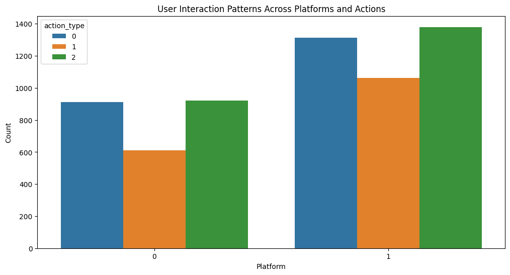

```python
import seaborn as sns
import matplotlib.pyplot as plt

# Using Seaborn to plot the bar graph
plt.figure(figsize=(12, 6))
sns.barplot(data=platform_action_summary, x='platform', y='count', hue='action_type')
plt.title('User Interaction Patterns Across Platforms and Actions')
plt.ylabel('Count')
plt.xlabel('Platform')
plt.show()
```

## Q4

**Original Question**:

**Probability and Statistics Question**: Given a product and its marketing campaigns, estimate the probability of a user purchasing the product after viewing an ad. Use causal knowledge to explain how different factors might affect this probability.

### Solution

#### Problem Solving Ideas and Tips

The task of estimating the probability of a user purchasing a product after viewing an ad involves both analysis and modeling. Here's a general approach:

1. **Understand the Effect of Different Channels**: Analyze how different marketing channels and campaigns influence user purchase behavior. This can be accomplished by comparing the conversion rates across various channels.
2. **Causal Analysis**: Incorporate causal inference to understand the true effect of viewing an ad on the purchasing decision. This might include using techniques like propensity score matching to compare users who saw the ad with those who didn't, but are otherwise similar.
3. **Feature Engineering**: Utilize the available data to create meaningful features that might affect purchase probability, such as user engagement, past purchase behavior, platform used, etc.
4. **Build a Probability Model**: Implement a statistical or machine learning model to predict the probability of purchase after viewing an ad. Logistic regression is a commonly used method for such binary classification problems.

#### Solution

1. **Data Preparation**: First, we need to join the relevant tables and create a binary target variable indicating whether a purchase happened after viewing an ad.
2. **Causal Analysis**: Apply techniques to measure the causal effect of viewing an ad.
3. **Modeling**: Fit a model to estimate the probability.

Below is the detailed Python code for these steps.

```python
import pandas as pd
from sklearn.model_selection import train_test_split
from sklearn.linear_model import LogisticRegression
from sklearn.metrics import roc_auc_score

# Assuming user_activity and marketing_campaigns are already dataframes
# Merge the two tables on relevant keys (e.g., campaign_id if available in user_activity)
data = pd.merge(user_activity, marketing_campaigns, how='inner', left_on='campaign_id', right_on='campaign_id')

# Create a binary target variable: 1 if action_type is 'purchase' after 'view', 0 otherwise
data['target'] = (data['action_type'].shift(-1) == 1) & (data['action_type'] == 2)
data['target'] = data['target'].astype(int)

# Select features - this could be refined based on feature analysis
features = ['budget', 'platform', 'channel'] # Add more relevant features

# Convert categorical variables to numerical ones using one-hot encoding
data_encoded = pd.get_dummies(data[features + ['target']], drop_first=True)

# Split the data into training and testing sets
X_train, X_test, y_train, y_test = train_test_split(data_encoded.drop('target', axis=1), data_encoded['target'], test_size=0.2)

# Create and fit logistic regression model
model = LogisticRegression()
model.fit(X_train, y_train)

# Predict probabilities on the test set
y_pred_prob = model.predict_proba(X_test)[:, 1]

# Evaluate the model (e.g., using AUC)
auc_score = roc_auc_score(y_test, y_pred_prob)
print(f'AUC Score: {auc_score}')
```

```
AUC Score: 0.5028432868395866
```

#### Causal Explanation:

Different factors can causally affect the probability of a user purchasing a product after viewing an ad:

- **Marketing Channel**: Different channels might have different levels of influence on users. For example, social media might have a more significant impact on younger audiences.
- **Platform**: User experience might differ across platforms (e.g., iOS, Android), affecting the probability of purchase.
- **Budget**: The quality and reach of a campaign might be influenced by its budget.
- **Time Factors**: Seasonality, timing of the campaign, and how long the ad is viewed might also play a role.

Causal relationships can be more thoroughly investigated using specific causal inference techniques like instrumental variables, difference-in-differences, etc.